# Investigating the shared bike usages in San Francisco

## by Shuai Guo

## Investigation Overview

In this presentation, we investigate the following three aspects of shared bike usage patterns

- Trip duration: how long people usually ride? Does trip duration affected by month or user type?
- Bike usage by month, day and hour: are there any particular month, day or hour that people ride the most?
- Station usage pattern at peak hours: where do people start and end their journey?

## Dataset Overview

This data set includes information about individual rides made in a bike-sharing system covering the greater San Francisco Bay area in 2017. The source data (Ford GoBike System Data) is available at : https://www.fordgobike.com/system-data.

## 1. Trip duration patterns

- How long do people usually ride?

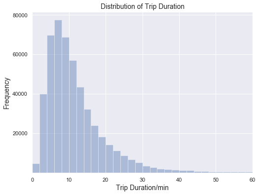

```python
# Distribution of the trip duration
bikeshare_data_clean['duration_min'] = bikeshare_data_clean['duration_sec']/60
bins = np.arange(0, bikeshare_data_clean['duration_min'].max() + 1 , 2)

fig, ax = plt.subplots(1,figsize=(8,6))
sns.distplot(bikeshare_data_clean.duration_min,bins = bins,kde=False)
ax.set_xlim(0,60)
ax.set_title('Distribution of Trip Duration',fontsize=14)
ax.set_xlabel('Trip Duration/min',fontsize=14)
ax.set_ylabel('Frequency',fontsize=14)
ax.set_yticks([20000,40000,60000,80000]);
```

* Riding time longer than 60 minutes are not considered here, since those outliers are likely induced by riders who didn't return the bike for multiple trips.

Insights:

1. People tend to ride around **8 minutes**.
2. Most people use shared bike for **short-distance trip** since they ride less than 30 minutes.

## 1. Trip duration patterns

- Does trip duration varies with month?

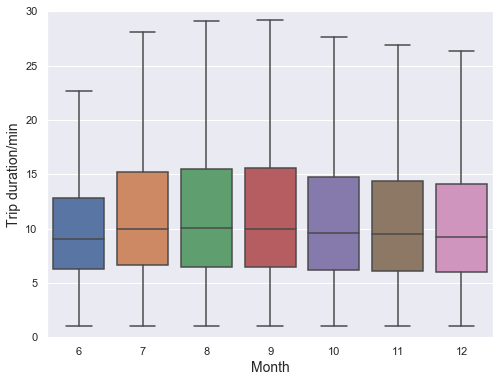

```python
# Boxplot for trip duration distribution at each month
fig, ax = plt.subplots(1,figsize=(8,6))
ax = sns.boxplot(x="month", y="duration_min", data=bikeshare_data_clean,showfliers = False)
ax.set_ylim(0,30)
ax.set_xlabel('Month',fontsize=14)
ax.set_ylabel('Trip duration/min',fontsize=14);
```

Insights:

1. No obvious difference between trip duration patterns at various months.
2. This is expected considering that San Francisco does not have distinct four seasons like other cities (e.g., New York).

## 1. Trip duration patterns

- Does user type influence trip durations?

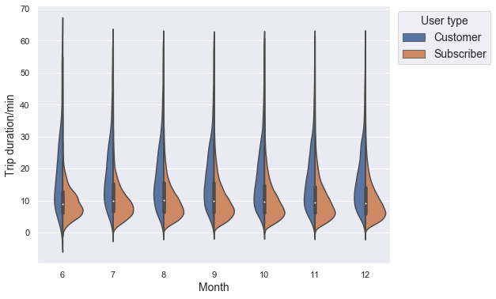

```python
# Violin plot
fig, ax = plt.subplots(1,figsize=(8,6))
ax = sns.violinplot(x="month", y="duration_min", hue="user_type",data=bikeshare_data_clean,split=True)
ax.set_xlabel('Month',fontsize=14)
ax.set_ylabel('Trip duration/min',fontsize=14)
ax.legend(title= 'User type',title_fontsize=14,bbox_to_anchor=(1.3, 1),fontsize=14);
```

Insights:

1. Subscribers tend to take **shorter trips** compared with single-time users.
2. Trip duration patterns for both subscribers and customers are almost the same at different months.

## 2. Bike usage patterns

- Which is the most popular month for bike usage?

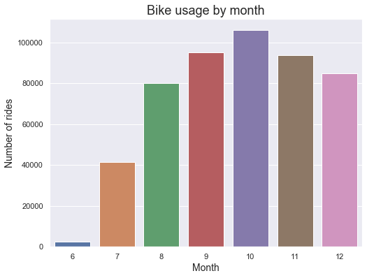

```python
# Bar plot
fig, ax = plt.subplots(1,figsize=(8,6))
ax = sns.countplot(x="month",data=bikeshare_data_clean)
ax.set_title('Bike usage by month',fontsize=18)
ax.set_xlabel('Month',fontsize=14)
ax.set_ylabel('Number of rides',fontsize=14);
```

Insights:

1. **October** sees the most shared bike usage.Towards winter or summer months, the number of rides decreases.
2. Autumn months have the most comfortable temperature for riding. As a result, people tend to use shared bike more often.

## 2. Bike usage patterns

- Which is the most popular day for bike usage?

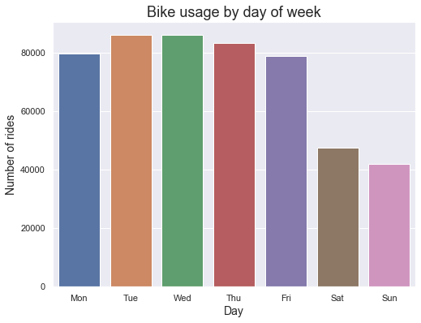

```python
# Bar plot
fig, ax = plt.subplots(1,figsize=(8,6))
ax = sns.countplot(x="weekday",data=bikeshare_data_clean)
ax.set_title('Bike usage by day of week',fontsize=18)
ax.set_xlabel('Day',fontsize=14)
ax.set_ylabel('Number of rides',fontsize=14)
ax.set_xticklabels(['Mon','Tue','Wed','Thu','Fri','Sat','Sun']);
```

Insights:

1. **Weekdays** see the most shared bike usage, the number of rides in weekends reduced around half.
2. People use shared bike mainly for commuting between home and work place.

## 2. Bike usage patterns

- Which is the most popular hour for bike usage?

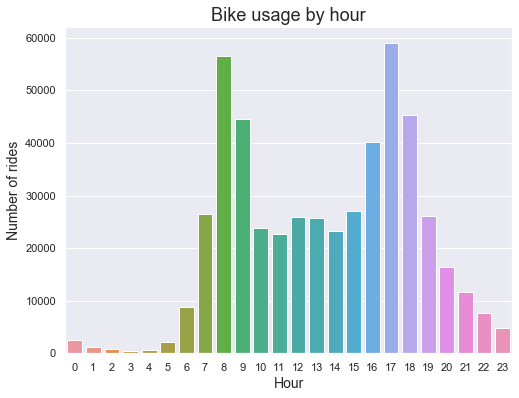

```python
# Bar plot
fig, ax = plt.subplots(1,figsize=(8,6))
ax = sns.countplot(x="hour",data=bikeshare_data_clean)
ax.set_title('Bike usage by hour',fontsize=18)
ax.set_xlabel('Hour',fontsize=14)
ax.set_ylabel('Number of rides',fontsize=14);
```

Insights:

1. **8am** and **17pm** see the most shared bike usage.
2. Those times correspond to the morning and afternoon rush hour when people commute between home and work place.

## 3. Station usage pattern at peak hours

- Where are the bike stations in San Francisco?

[figure not shown]

```python
# Only retain usage info during weekdays
stations = bikeshare_data_clean.query('weekday<5').reset_index()

# Convert geo-coordinates, from GPS to x/y web mercator
inProj, outProj = Proj(init='epsg:4326'), Proj(init='epsg:3857')
stations['start_X'], stations['start_Y'] = transform(inProj, outProj, stations['start_station_longitude'].tolist(),
                             stations['start_station_latitude'].tolist())
stations['end_X'], stations['end_Y'] = transform(inProj, outProj, stations['end_station_longitude'].tolist(),
                             stations['end_station_latitude'].tolist())

# Download map (San Francisco city)
west, south, east, north = (-122.461049,37.74116,-122.376935,37.816608)
sf_img, sf_ext = cx.bounds2img(west,south,east,north,ll=True,
                               source=cx.providers.Wikimedia,
                               zoom=14)

f, ax = plt.subplots(1, figsize=(10, 10))

ax.imshow(sf_img, extent=sf_ext)
sca = ax.scatter(stations.start_X,stations.start_Y,marker='o',c='g',s=30,label='Bike stations')
ax.set_xlim(sf_ext[0:2])
ax.set_ylim(sf_ext[2:])
ax.set_title('Bike stations in San Francisco',fontsize=16)
ax.set_yticklabels([])
ax.set_xticklabels([])
ax.legend(bbox_to_anchor=(1.3, 1),fontsize=14);
```

Insights:

1. Bike stations are scattered throughout the city with a fairly even distance between stations

## 3. Station usage pattern at peak hours

- Where do people start and end their trips at 8am?

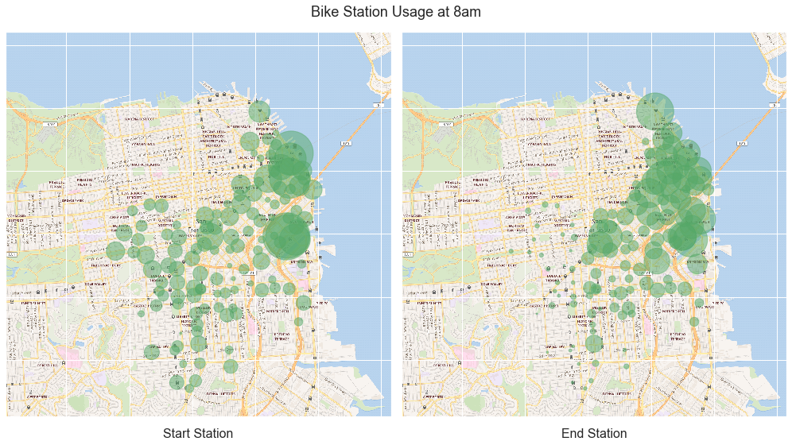

```python
# Display patterns in the morning
f, axs = plt.subplots(1,2, figsize=(14, 14))
trip = ['Start Station','End Station']

for i,ax in enumerate(axs):
    # Display map
    ax.imshow(sf_img, extent=sf_ext)
    # Display bike stations
    ax.scatter(sf_am[i].iloc[:,1],sf_am[i].iloc[:,2],c='g',s=sf_am[i].iloc[:,3],alpha=0.5)
    ax.set_xlim(sf_ext[0:2])
    ax.set_ylim(sf_ext[2:])
    ax.set_yticklabels([])
    ax.set_xticklabels([])
    ax.set_xlabel(trip[i],fontsize=16)

f.suptitle('Bike Station Usage at 8am',fontsize=18)
f.tight_layout()
f.subplots_adjust(top=1.4)
```

Insights:

1. Many rides start near BART transit stations, ferry dock and the northern end of Caltrain station.
2. Those rides end in downtown San Francisco and Financial District.

## 3. Station usage pattern at peak hours

- Where do people start and end their trips at 17am?

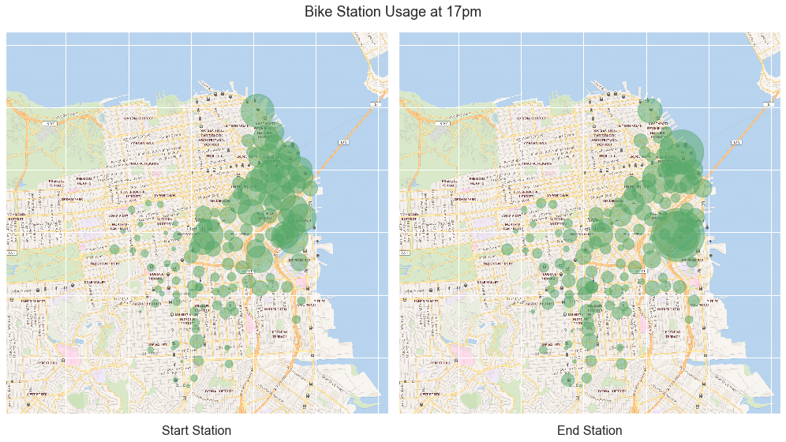

```python
# Display patterns in the afternoon
f, axs = plt.subplots(1,2, figsize=(14, 14))
trip = ['Start Station','End Station']

for i,ax in enumerate(axs):
    # Display map
    ax.imshow(sf_img, extent=sf_ext)
    # Display bike stations
    ax.scatter(sf_pm[i].iloc[:,1],sf_pm[i].iloc[:,2],c='g',s=sf_pm[i].iloc[:,3],alpha=0.5)
    ax.set_xlim(sf_ext[0:2])
    ax.set_ylim(sf_ext[2:])
    ax.set_yticklabels([])
    ax.set_xticklabels([])
    ax.set_xlabel(trip[i],fontsize=16)

f.suptitle('Bike Station Usage at 17pm',fontsize=18)
f.tight_layout()
f.subplots_adjust(top=1.4)
```

Insights:

1. Opposite trend can be observed: many rides start at business centers and end at major transit stations.
2. People take public transportations from outside of the city and use shard bikes to commute from major transit terminals to their workplaces.